# Play with metaphors

Bodo

23/05/2021

## Load packages and data:

Load packages:

```r
library(tidyverse)
library(ggcorrplot)
```

Load data:

```r
totals <- read_csv('../data/totals.csv')
corpus_size <- read_csv('../data/corpus_size.csv')
adj_noun <- read_csv('../data/adj_noun_spk_generic.csv')
deverbs <- read_csv('../data/deverb_noun_spk_generic.csv')
```

Show each:

```r
# Totals (adjective and noun overall frequency):

sample_n(totals, 4)
```

```
## # A tibble: 4 x 2
##   word      freq
##   <chr>    <dbl>
## 1 smallest   458
## 2 tiniest     61
## 3 income    6911
## 4 growing   8304
```

```r
# Size of individual files:

sample_n(corpus_size, 4)
```

```
## # A tibble: 4 x 2
##   file               freq
##   <chr>             <dbl>
## 1 w_spok_2003.txt 4410232
## 2 w_spok_2002.txt 4319779
## 3 w_spok_1993.txt 4424200
## 4 w_spok_2006.txt 4335122
```

```r
# Adjective-noun combinations:

sample_n(adj_noun, 4)
```

```
## # A tibble: 4 x 4
##   adj      noun       adj_noun          freq
##   <chr>    <chr>      <chr>            <dbl>
## 1 smallest revenue    smallest revenue     0
## 2 low      proportion low proportion       0
## 3 huger    benefit    huger benefit        0
## 4 lowest   profit     lowest profit        0
```

```r
# Adjective-noun combinations with deverbals:

sample_n(deverbs, 4)
```

```
## # A tibble: 4 x 4
##   adj      noun    adj_noun          freq
##   <chr>    <chr>   <chr>            <dbl>
## 1 dropping profit  dropping profit      0
## 2 growing  cost    growing cost        12
## 3 slumping benefit slumping benefit     0
## 4 growing  gain    growing gain         0
```

These will have to be merged. We will use “adj_noun” as the main tibble to be analyzed.

## Merge and process data:

Merge totals into there:

```r
# Adjective-noun:

adj_noun$noun_N <- totals[match(adj_noun$noun, totals$word), ]$freq
adj_noun$adj_N <- totals[match(adj_noun$adj, totals$word), ]$freq

# Deverbal adjective-noun:

deverbs$noun_N <- totals[match(deverbs$noun, totals$word), ]$freq
deverbs$adj_N <- totals[match(deverbs$adj, totals$word), ]$freq
```

Mark whether an adjective is vertical or size-based:

```r
verts <- c('high', 'higher', 'highest',
           'low', 'lower', 'lowest')

adj_noun <- mutate(adj_noun,
                   type = ifelse(adj %in% verts, 'vertical', 'size'))
```

Show:

```r
sample_n(adj_noun, 4)
```

```
## # A tibble: 4 x 7
##   adj      noun   adj_noun         freq noun_N adj_N type
##   <chr>    <chr>  <chr>           <dbl>  <dbl> <dbl> <chr>
## 1 smallest income smallest income     0   6911   458 size
## 2 tiny     profit tiny profit         0   5835  4304 size
## 3 smallest volume smallest volume     0   1324   458 size
## 4 large    volume large volume       23   1324 23666 size
```

For the deverbal ones that’s vertical vs. neutral:

```r
neutral <- c('growing', 'shrinking',
             'increasing', 'decreasing')

deverbs <- mutate(deverbs,
                  type = ifelse(adj %in% neutral, 'neutral', 'vertical'))
```

Show:

```r
sample_n(deverbs, 4)
```

```
## # A tibble: 4 x 7
##   adj        noun     adj_noun            freq noun_N adj_N type
##   <chr>      <chr>    <chr>              <dbl>  <dbl> <dbl> <chr>
## 1 descending benefit  descending benefit     0   9941   197 vertical
## 2 soaring    standard soaring standard       0   8580   340 vertical
## 3 dipping    gain     dipping gain           0 114460   113 vertical
## 4 ascending  cost     ascending cost         0  20025    23 vertical
```

## Compute PMI

Compute total frequency across the entire corpus. Will use this to normalize the frequencies:

```r
N <- sum(totals$freq)
```

Compute pointwise mutual information, which is:

log(p(x, y) / (p(x) * p(y)))

First, we need the normalized frequencies:

```r
# Adjective-noun:

adj_noun <- adj_noun %>%
  mutate(freq = ifelse(freq == 0, 0.1, freq)) %>% # not sure if this is legitimate
  mutate(p_x_y = freq / N,
         p_x = noun_N / N,
         p_y = adj_N / N,
         p_xy = p_x * p_y,
         pmi = p_x_y / p_xy,
         pmi = log(pmi)) %>%
  select(-(p_x_y:p_xy))

# Deverbal adjective-noun:

deverbs <- deverbs %>%
  mutate(freq = ifelse(freq == 0, 0.1, freq)) %>% # not sure if this is legitimate
  mutate(p_x_y = freq / N,
         p_x = noun_N / N,
         p_y = adj_N / N,
         p_xy = p_x * p_y,
         pmi = p_x_y / p_xy,
         pmi = log(pmi)) %>%
  select(-(p_x_y:p_xy))
```

Check:

```r
sample_n(adj_noun, 10)
```

```
## # A tibble: 10 x 8
##    adj     noun     adj_noun        freq noun_N adj_N type        pmi
##    <chr>   <chr>    <chr>          <dbl>  <dbl> <dbl> <chr>     <dbl>
##  1 low     cost     low cost       119    20025 97435 vertical -3.06
##  2 higher  salary   higher salary    4     1295  7410 vertical -1.14
##  3 huge    quantity huge quantity    3      307 11889 size     -0.461
##  4 large   revenue  large revenue    2     2779 23666 size     -3.76
##  5 larger  earning  larger earning   0.1   6054  3925 size     -5.74
##  6 largest loss     largest loss    12     7983  4984 size     -1.46
##  7 low     amount   low amount      10    11750 97435 vertical -5.01
##  8 high    income   high income     48     6911 48298 vertical -2.20
##  9 bigger  earning  bigger earning   0.1   6054  5458 size     -6.07
## 10 tiniest cost     tiniest cost     1    20025    61 size     -0.465
```

```r
sample_n(deverbs, 10)
```

```
## # A tibble: 10 x 8
##    adj          noun      adj_noun               freq noun_N adj_N type      pmi
##    <chr>        <chr>     <chr>                 <dbl>  <dbl> <dbl> <chr>   <dbl>
##  1 surging      pay       surging pay             0.1  39693   208 vertic… -4.68
##  2 dropping     quantity  dropping quantity       0.1    307  1586 vertic… -1.85
##  3 shrinking    salary    shrinking salary        0.1   1295   370 neutral -1.83
##  4 surging      benefit   surging benefit         0.1   9941   208 vertic… -3.29
##  5 growing      profit    growing profit          2     5835  8304 neutral -3.45
##  6 shrinking    tax       shrinking tax           1    39724   370 neutral -2.95
##  7 descending   volume    descending volume       0.1   1324   197 vertic… -1.22
##  8 increasing   cost      increasing cost        10    20025  4324 neutral -2.42
##  9 skyrocketing proporti… skyrocketing proport…   0.1   1506   156 vertic… -1.12
## 10 dipping      revenue   dipping revenue         0.1   2779   113 vertic… -1.41
```

Check the distribution of PMI:

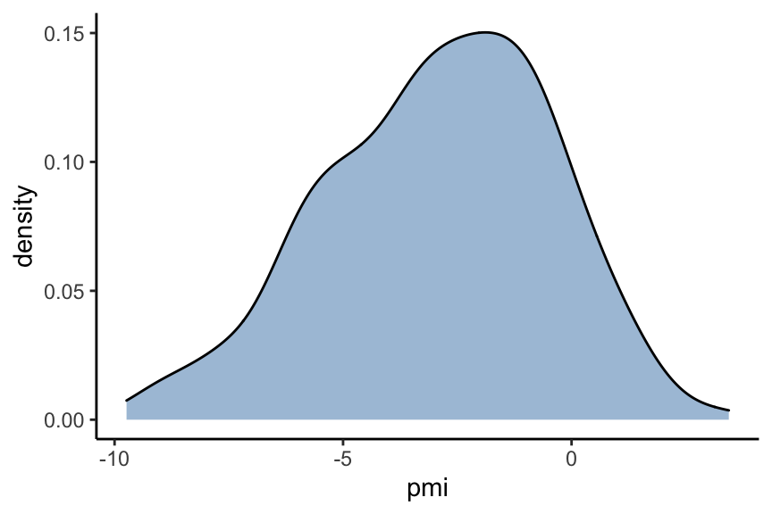

```r
adj_noun %>% ggplot(aes(x = pmi)) +
  geom_density(col = 'black', fill = 'steelblue', alpha = 0.5) +
  theme_classic()
```

Same for deverbal:

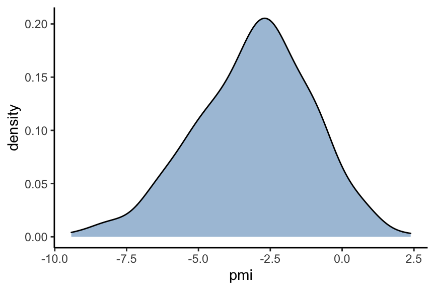

```r
deverbs %>% ggplot(aes(x = pmi)) +
  geom_density(col = 'black', fill = 'steelblue', alpha = 0.5) +
  theme_classic()
```

## Average PMI for different nouns

Compute the average vertical / size PMI for different nouns:

```r
type_avgs <- adj_noun %>%
  filter(!is.infinite(pmi)) %>%
  group_by(noun, type) %>%
  summarize(pmi = mean(pmi, na.rm = TRUE))
```

Plot this:

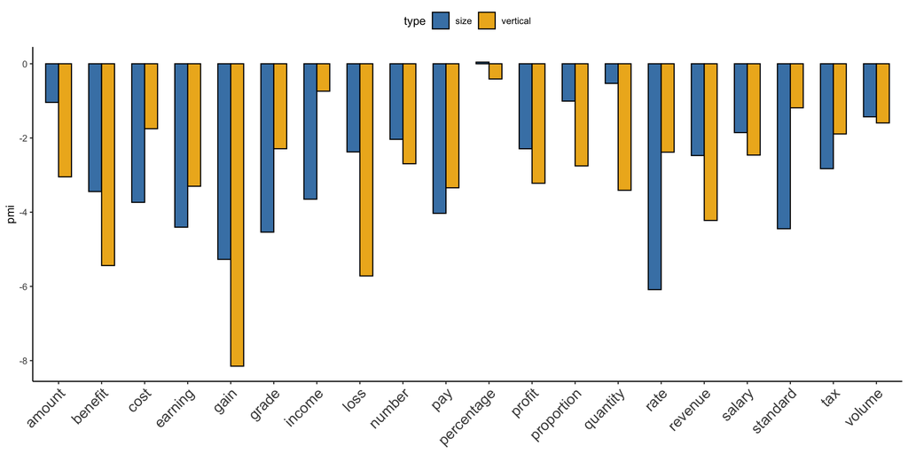

```r
adj_p <- type_avgs %>% ggplot(aes(x = noun,
                         fill = type,
                         y = pmi)) +
  scale_fill_manual(values = c('steelblue', 'goldenrod2')) +
  geom_col(position = position_dodge(0.6),
           width = 0.6,
           col = 'black') +
  xlab(NULL) +
  theme_classic() +
  theme(legend.position = 'top',
        axis.text.x = element_text(angle = 45, hjust = 1, size = 14))

# Show and save:

adj_p
```

```r
ggsave(plot = adj_p, filename = '../figures/adjectives.pdf',
       width = 16, height = 6)
```

Compute the average vertical / size PMI for different nouns for the deverbals:

```r
deverb_type_avgs <- deverbs %>%
  filter(!is.infinite(pmi)) %>%
  group_by(noun, type) %>%
  summarize(pmi = mean(pmi, na.rm = TRUE))
```

Plot this:

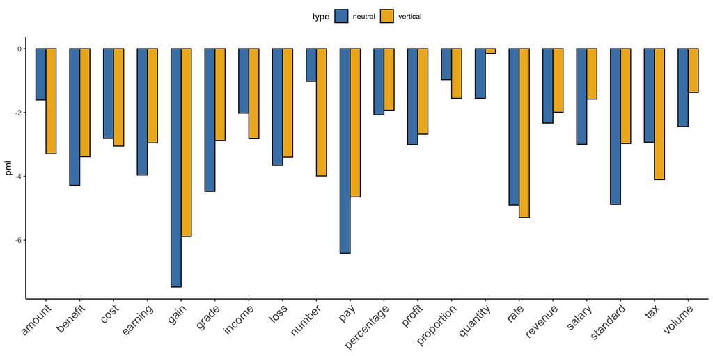

```r
deverb_p <- deverb_type_avgs %>% ggplot(aes(x = noun,
                         fill = type,
                         y = pmi)) +
  scale_fill_manual(values = c('steelblue', 'goldenrod2')) +
  geom_col(position = position_dodge(0.6),
           width = 0.6,
           col = 'black') +
  xlab(NULL) +
  theme_classic() +
  theme(legend.position = 'top',
        axis.text.x = element_text(angle = 45, hjust = 1, size = 14))

# Show and save:

deverb_p
```

```r
ggsave(plot = deverb_p, filename = '../figures/deverb_adjectives.pdf',
       width = 16, height = 6)
```

## Create a relative PMI score

Create a relative PMI score that looks at the relative degree to which something is more vertical or more size-based (or conversely, more “neutral”).

```r
rel_pmi_avgs <- type_avgs %>%
  pivot_wider(values_from = pmi, names_from = type) %>%
  mutate(vertical_bias = vertical - size)
```

Make a plot of this:

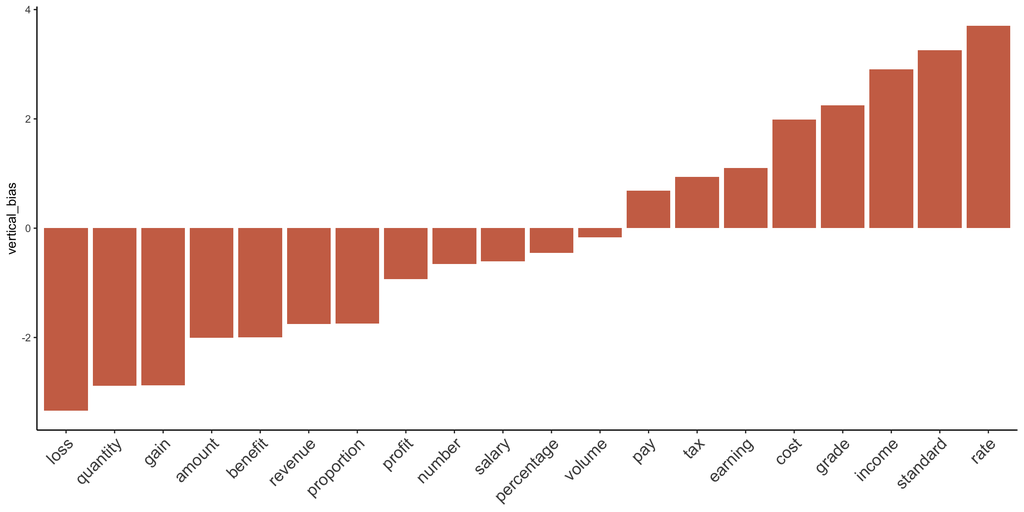

```r
rel_pmi_p <- rel_pmi_avgs %>%
  ggplot(aes(x = reorder(noun, vertical_bias), y = vertical_bias)) +
  geom_col(fill = 'salmon3') +
  xlab(NULL) +
  theme_classic() +
  theme(legend.position = 'top',
        axis.text.x = element_text(angle = 45, hjust = 1, size = 14))

# Show and save:

rel_pmi_p
```

```r
ggsave(plot = rel_pmi_p, filename = '../figures/relative_pmi.pdf',
       width = 12, height = 6)
```

Same for the deverbal ones:

```r
deverb_rel_pmi_avgs <- deverb_type_avgs %>%
  pivot_wider(values_from = pmi, names_from = type) %>%
  mutate(vertical_bias = vertical - neutral)
```

Make a plot of this:

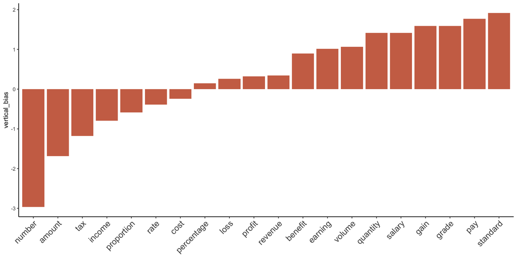

```r
deverb_rel_pmi_p <- deverb_rel_pmi_avgs %>%
  ggplot(aes(x = reorder(noun, vertical_bias), y = vertical_bias)) +
  geom_col(fill = 'salmon3') +
  xlab(NULL) +
  theme_classic() +
  theme(legend.position = 'top',
        axis.text.x = element_text(angle = 45, hjust = 1, size = 14))

# Show and save:

deverb_rel_pmi_p
```

```r
ggsave(plot = deverb_rel_pmi_p, filename = '../figures/deverb_relative_pmi.pdf',
       width = 12, height = 6)
```

See whether the two are correlated:

```r
deverb_rel_pmi_avgs <- rename(deverb_rel_pmi_avgs,
                              deverb_bias = vertical_bias)

both_avgs <- rel_pmi_avgs %>% select(-size, -vertical) %>%
  right_join(deverb_rel_pmi_avgs) %>%
  select(-neutral, -vertical)
```

Make a plot of this:

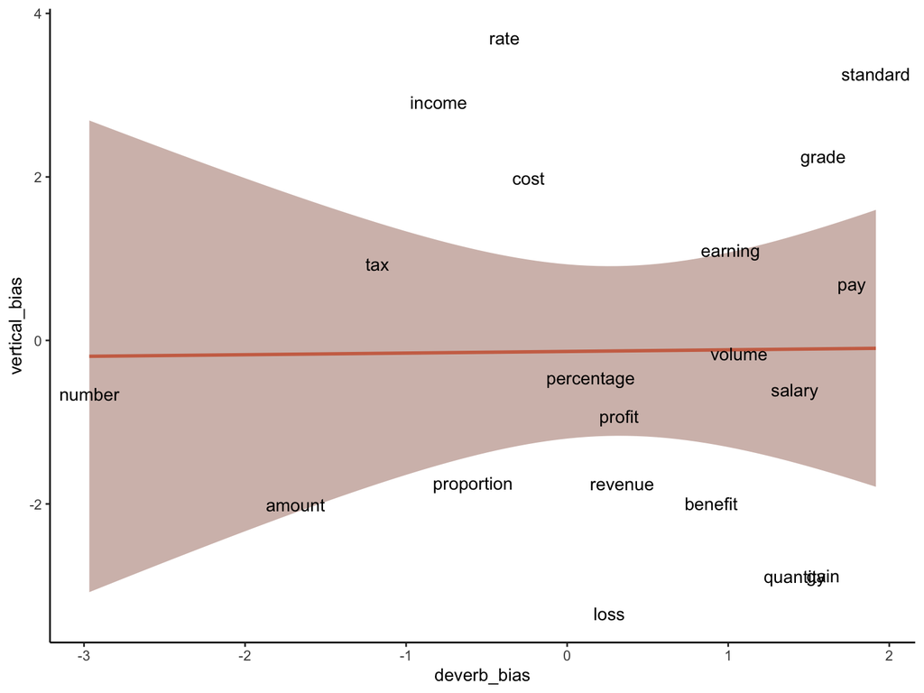

```r
cor_p <- both_avgs %>%
  ggplot(aes(x = deverb_bias, y = vertical_bias, label = noun)) +
  geom_smooth(method = 'lm', col = 'salmon3', fill = 'salmon4') +
  geom_text() +
  theme_classic()

# Show and save:

cor_p
```

```r
ggsave(plot = cor_p, filename = '../figures/correlation.pdf',
       width = 6, height = 4)
```

## Check the correlation for individual lexical items within adjective set

If something prefers high, does it also prefer low; if something prefers, tiny, does it also prefer the other size terms etc.?

```r
# Lemmatize:

adj_noun <- mutate(adj_noun,
                   item = ifelse(adj %in% c('higher', 'highest'), 'high', adj),
                   item = ifelse(item %in% c('lower', 'lowest'), 'low', item),
                   item = ifelse(item %in% c('bigger', 'biggest'), 'big', item),
                   item = ifelse(item %in% c('smaller', 'smallest'), 'small', item),
                   item = ifelse(item %in% c('tinier', 'tiniest'), 'tiny', item),
                   item = ifelse(item %in% c('huger', 'hugest'), 'huge', item),
                   item = ifelse(item %in% c('larger', 'largest'), 'huge', item))
```

Get averages per item:

```r
item_avgs <- adj_noun %>% group_by(noun, item) %>%
  summarize(pmi = mean(pmi)) %>% ungroup()
item_avgs
```

```
## # A tibble: 140 x 3
##    noun    item      pmi
##    <chr>   <chr>   <dbl>
##  1 amount  big   -3.95
##  2 amount  high  -2.46
##  3 amount  huge  -0.493
##  4 amount  large -0.119
##  5 amount  low   -3.63
##  6 amount  small -0.0334
##  7 amount  tiny  -0.362
##  8 benefit big   -3.84
##  9 benefit high  -5.93
## 10 benefit huge  -2.61
## # … with 130 more rows
```

Make this into wide format for easier cross-correlations:

```r
item_avgs <- item_avgs %>% pivot_wider(values_from = pmi, names_from = item)

item_avgs
```

```
## # A tibble: 20 x 8
##    noun         big    high    huge  large    low   small   tiny
##    <chr>      <dbl>   <dbl>   <dbl>  <dbl>  <dbl>   <dbl>  <dbl>
##  1 amount     -3.95 -2.46   -0.493  -0.119 -3.63  -0.0334 -0.362
##  2 benefit    -3.84 -5.93   -2.61   -4.63  -4.94  -4.57   -2.92
##  3 cost       -4.27 -1.87   -2.89   -5.33  -1.63  -5.73   -2.08
##  4 earning    -6.09 -2.97   -3.74   -7.53  -3.63  -4.77   -2.42
##  5 gain       -5.11 -7.68   -4.43   -7.48  -8.61  -6.02   -5.36
##  6 grade      -7.02 -2.15   -3.21   -7.47  -2.43  -5.47   -2.35
##  7 income     -5.09 -0.794  -2.35   -5.36  -0.683 -4.90   -2.55
##  8 loss       -2.09 -5.12   -1.22   -3.02  -6.32  -4.05   -2.70
##  9 number     -3.27 -2.30   -1.54   -0.285 -3.09  -1.39   -2.86
## 10 pay        -4.04 -3.13   -3.18   -5.32  -3.56  -4.75   -4.30
## 11 percentage -1.90  0.505   0.469   0.202 -1.32   0.970   0.296
## 12 profit     -2.68 -1.90   -1.41   -3.81  -4.54  -2.77   -2.38
## 13 proportion -2.70 -1.22   -0.299  -0.620 -4.28  -1.36   -0.261
## 14 quantity   -4.11 -2.99    0.983   0.843 -3.83  -1.02    0.562
## 15 rate       -7.91 -2.13   -5.13   -7.13  -2.64  -7.36   -4.24
## 16 revenue    -4.08 -4.55   -1.30   -3.76  -3.90  -3.22   -1.64
## 17 salary     -3.18 -1.42   -0.676  -3.69  -3.50  -2.86   -0.877
## 18 standard   -6.67 -0.0710 -3.63   -7.88  -2.30  -5.12   -1.77
## 19 tax        -2.51 -1.70   -1.90   -3.82  -2.08  -4.02   -3.17
## 20 volume     -3.44 -1.26   -0.0624 -0.574 -1.93  -2.52   -0.899
```

Cross-correlate and order them by vertical versus horizontal:

```r
cor_matrix <- cor(select(item_avgs, big:tiny))

cor_matrix <- cor_matrix[, c('high', 'low', 'big', 'small', 'huge', 'tiny', 'large')]
cor_matrix <- cor_matrix[c('high', 'low', 'big', 'small', 'huge', 'tiny', 'large'), ]
```

Show:

```r
round(cor_matrix, 2)
```

```
##       high   low   big small huge tiny large
## high  1.00  0.85  0.03  0.33 0.30 0.53  0.23
## low   0.85  1.00 -0.13  0.11 0.14 0.37  0.10
## big   0.03 -0.13  1.00  0.68 0.75 0.37  0.73
## small 0.33  0.11  0.68  1.00 0.90 0.78  0.91
## huge  0.30  0.14  0.75  0.90 1.00 0.83  0.92
## tiny  0.53  0.37  0.37  0.78 0.83 1.00  0.70
## large 0.23  0.10  0.73  0.91 0.92 0.70  1.00
```

Make a plot of this:

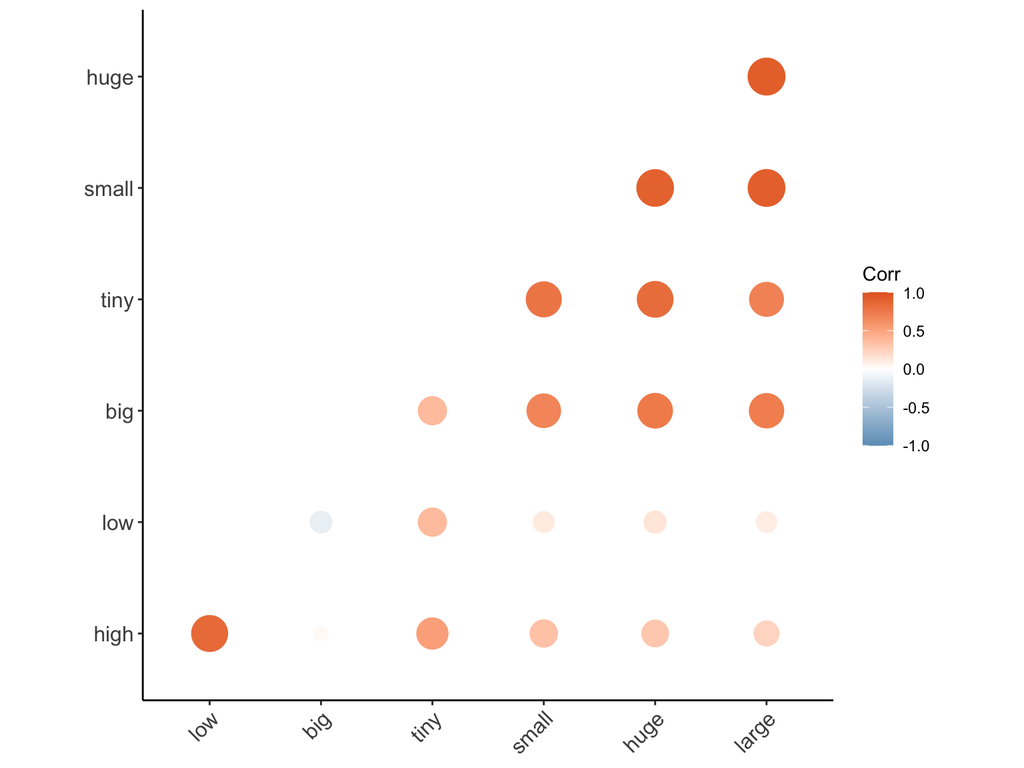

```r
cor_p <- ggcorrplot(cor_matrix, type = "lower", hc.order = TRUE,
           method = 'circle',
           outline.col = "white",
           ggtheme = ggplot2::theme_classic,
           colors = c("#6D9EC1", "white", "#E46726"))

cor_p
```

```r
ggsave(plot = cor_p, filename = '../figures/cor_p.pdf')
```

Append rising and falling in there for now:

```r
big_df <- bind_rows(adj_noun, deverbs) %>%
  mutate(item = ifelse(adj %in% c('higher', 'highest'), 'high', adj),
         item = ifelse(item %in% c('lower', 'lowest'), 'low', item),
         item = ifelse(item %in% c('bigger', 'biggest'), 'big', item),
         item = ifelse(item %in% c('smaller', 'smallest'), 'small', item),
         item = ifelse(item %in% c('tinier', 'tiniest'), 'tiny', item),
         item = ifelse(item %in% c('huger', 'hugest'), 'huge', item),
         item = ifelse(item %in% c('larger', 'largest'), 'huge', item))
```

Get averages per item:

```r
item_avgs <- big_df %>% group_by(noun, item) %>%
  summarize(pmi = mean(pmi)) %>% ungroup()
item_avgs
```

```
## # A tibble: 480 x 3
##    noun   item          pmi
##    <chr>  <chr>       <dbl>
##  1 amount ascending  -1.26
##  2 amount big        -3.95
##  3 amount climbing   -4.76
##  4 amount decreasing -0.825
##  5 amount descending -3.41
##  6 amount dipping    -2.85
##  7 amount dropping   -5.49
##  8 amount falling    -6.08
##  9 amount growing    -3.05
## 10 amount high       -2.46
## # … with 470 more rows
```

Make this into wide format for easier cross-correlations:

```r
item_avgs <- item_avgs %>% pivot_wider(values_from = pmi, names_from = item)

item_avgs
```

```
## # A tibble: 20 x 25
##    noun  ascending   big climbing decreasing descending dipping dropping falling
##    <chr>     <dbl> <dbl>    <dbl>      <dbl>      <dbl>   <dbl>    <dbl>   <dbl>
##  1 amou…    -1.26  -3.95    -4.76     -0.825     -3.41   -2.85     -5.49   -6.08
##  2 bene…    -1.09  -3.84    -4.59     -2.96      -3.24   -2.68     -5.33   -5.91
##  3 cost     -1.79  -4.27    -5.29     -3.66      -3.94   -3.38     -6.03   -6.61
##  4 earn…    -0.596 -6.09    -4.09     -2.46      -2.74   -2.19     -4.83   -5.42
##  5 gain     -3.54  -5.11    -7.03     -5.40      -5.68   -5.13     -7.77   -8.36
##  6 grade    -0.531 -7.02    -4.03     -2.40      -2.68   -2.12     -4.76   -3.05
##  7 inco…    -0.729 -5.09    -4.23     -0.295     -2.88   -2.32     -4.96   -3.25
##  8 loss     -0.873 -2.09    -4.37     -2.74      -3.02   -2.46     -5.11   -5.69
##  9 numb…    -2.63  -3.27    -6.13     -0.812     -4.78   -4.22     -6.87   -4.46
## 10 pay      -2.48  -4.04    -5.97     -4.35      -4.62   -4.07     -6.71   -4.99
## 11 perc…     0.370 -1.90    -3.13     -1.50      -1.78   -1.22     -3.86   -4.45
## 12 prof…    -0.559 -2.68    -4.06     -2.43      -2.71   -2.15     -4.79   -5.38
## 13 prop…     0.795 -2.70    -2.70     -1.07      -1.35   -0.797    -3.44   -4.02
## 14 quan…     2.39  -4.11    -1.11      0.517      0.238   0.793    -1.85   -2.43
## 15 rate     -3.19  -7.91    -6.68     -5.05      -5.33   -4.78     -7.42   -8.00
## 16 reve…     0.182 -4.08    -3.32     -1.69      -1.97   -1.41     -4.05   -2.33
## 17 sala…     0.946 -3.18    -2.55     -0.923     -1.20   -0.646    -3.29   -3.87
## 18 stan…    -0.945 -6.67    -4.44     -2.81      -3.09   -2.54     -5.18   -3.46
## 19 tax      -2.48  -2.51    -5.98     -2.04      -4.63   -4.07     -6.71   -4.30
## 20 volu…     0.924 -3.44    -2.57     -0.945     -1.22   -0.668    -3.31   -3.90
## # … with 16 more variables: growing <dbl>, high <dbl>, huge <dbl>,
## #   increasing <dbl>, large <dbl>, low <dbl>, plummeting <dbl>, plunging <dbl>,
## #   rising <dbl>, shrinking <dbl>, skyrocketing <dbl>, slumping <dbl>,
## #   small <dbl>, soaring <dbl>, surging <dbl>, tiny <dbl>
```

Cross-correlate and plot:

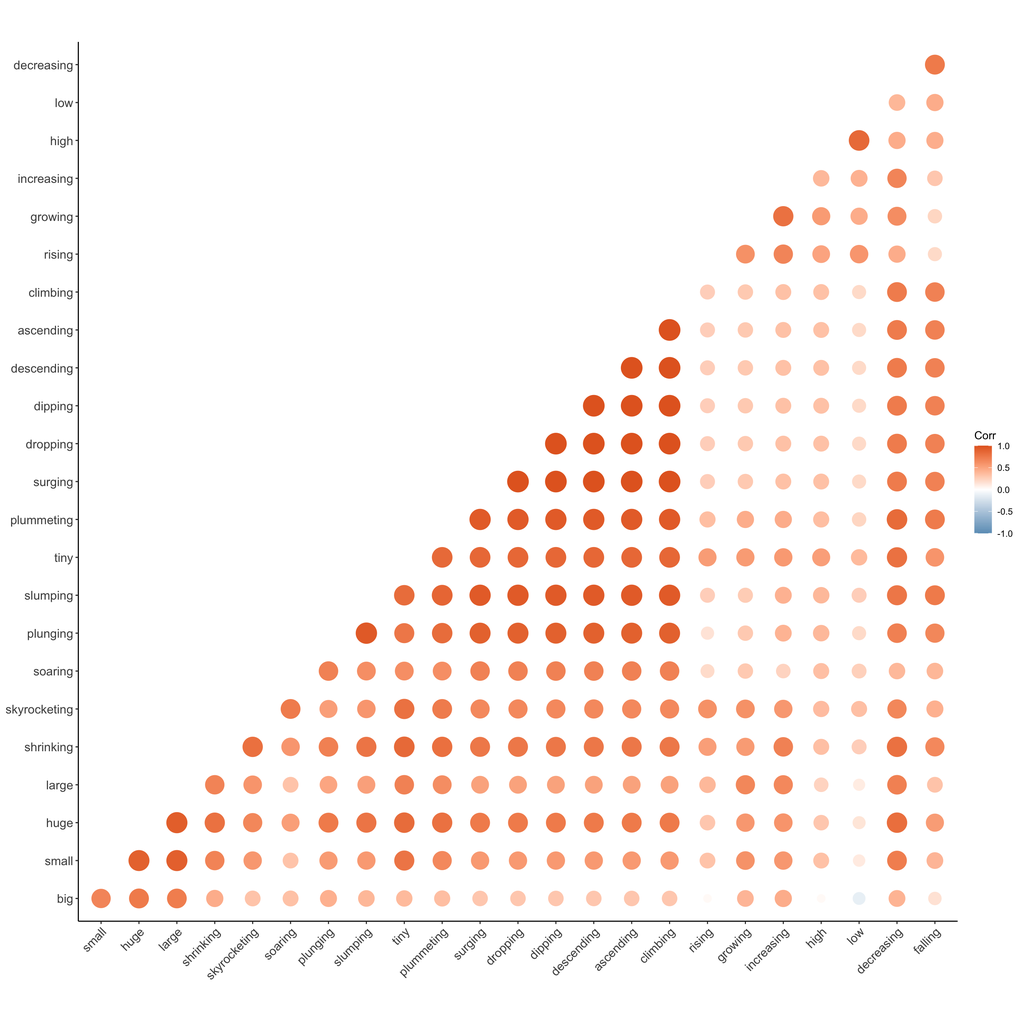

```r
cor_matrix <- cor(select(item_avgs, ascending:tiny))

cor_p <- ggcorrplot(cor_matrix, type = "lower", hc.order = TRUE,
           method = 'circle',
           outline.col = "white",
           ggtheme = ggplot2::theme_classic,
           colors = c("#6D9EC1", "white", "#E46726"))

cor_p
```

```r
ggsave(plot = cor_p, filename = '../figures/big_cor_p.pdf')
```

Show in markdown:

```r
round(cor_matrix, 2)
```

```
##              ascending   big climbing decreasing descending dipping dropping
## ascending         1.00  0.30     1.00       0.74       1.00    1.00     1.00
## big               0.30  1.00     0.30       0.41       0.30    0.30     0.30
## climbing          1.00  0.30     1.00       0.74       1.00    1.00     1.00
## decreasing        0.74  0.41     0.74       1.00       0.74    0.74     0.74
## descending        1.00  0.30     1.00       0.74       1.00    1.00     1.00
## dipping           1.00  0.30     1.00       0.74       1.00    1.00     1.00
## dropping          1.00  0.30     1.00       0.74       1.00    1.00     1.00
## falling           0.70  0.16     0.70       0.75       0.70    0.70     0.70
## growing           0.29  0.40     0.29       0.63       0.29    0.29     0.29
## high              0.33  0.03     0.33       0.45       0.33    0.33     0.33
## huge              0.75  0.75     0.75       0.82       0.75    0.75     0.75
## increasing        0.33  0.45     0.33       0.68       0.33    0.33     0.33
## large             0.51  0.73     0.51       0.71       0.51    0.51     0.51
## low               0.20 -0.13     0.20       0.39       0.20    0.20     0.20
## plummeting        0.94  0.35     0.94       0.84       0.94    0.94     0.94
## plunging          0.90  0.43     0.90       0.71       0.90    0.90     0.90
## rising            0.26  0.03     0.26       0.45       0.26    0.26     0.26
## shrinking         0.76  0.45     0.76       0.80       0.76    0.76     0.76
## skyrocketing      0.66  0.32     0.66       0.67       0.66    0.66     0.66
## slumping          0.94  0.39     0.94       0.77       0.94    0.94     0.94
## small             0.56  0.68     0.56       0.73       0.56    0.56     0.56
## soaring           0.70  0.33     0.70       0.38       0.70    0.70     0.70
## surging           1.00  0.30     1.00       0.74       1.00    1.00     1.00
## tiny              0.86  0.37     0.86       0.80       0.86    0.86     0.86
##              falling growing high huge increasing large   low plummeting
## ascending       0.70    0.29 0.33 0.75       0.33  0.51  0.20       0.94
## big             0.16    0.40 0.03 0.75       0.45  0.73 -0.13       0.35
## climbing        0.70    0.29 0.33 0.75       0.33  0.51  0.20       0.94
## decreasing      0.75    0.63 0.45 0.82       0.68  0.71  0.39       0.84
## descending      0.70    0.29 0.33 0.75       0.33  0.51  0.20       0.94
## dipping         0.70    0.29 0.33 0.75       0.33  0.51  0.20       0.94
## dropping        0.70    0.29 0.33 0.75       0.33  0.51  0.20       0.94
## falling         1.00    0.22 0.44 0.54       0.30  0.32  0.45       0.74
## growing         0.22    1.00 0.55 0.57       0.80  0.67  0.45       0.45
## high            0.44    0.55 1.00 0.30       0.38  0.23  0.85       0.35
## huge            0.54    0.57 0.30 1.00       0.59  0.92  0.14       0.80
## increasing      0.30    0.80 0.38 0.59       1.00  0.66  0.42       0.45
## large           0.32    0.67 0.23 0.92       0.66  1.00  0.10       0.63
## low             0.45    0.45 0.85 0.14       0.42  0.10  1.00       0.22
```

[output cut: 45 more lines]

```
## high            0.33 0.53
## huge            0.75 0.83
## increasing      0.33 0.56
## large           0.51 0.70
## low             0.20 0.37
## plummeting      0.94 0.85
## plunging        0.90 0.77
## rising          0.26 0.54
## shrinking       0.76 0.85
## skyrocketing    0.66 0.80
## slumping        0.94 0.83
## small           0.56 0.78
## soaring         0.70 0.62
## surging         1.00 0.86
## tiny            0.86 1.00
```